# Risk Factor Analysis

## Outcome Variable

**Outcome Variable:** co_occurence

## Predictor Variables

**Intervention Variable:** ever_wasted06

**Adjustment Set:**

unadjusted

## Stratifying Variables

The analysis was stratified on these variable(s):

- studyid
- country

## Data Summary

| studyid | country | ever_wasted06 | co_occurence | n_cell | n |
| --- | --- | --- | --- | --- | --- |
| ki0047075b-MAL-ED | BANGLADESH | 0 | 0 | 165 | 221 |
| ki0047075b-MAL-ED | BANGLADESH | 0 | 1 | 5 | 221 |
| ki0047075b-MAL-ED | BANGLADESH | 1 | 0 | 42 | 221 |
| ki0047075b-MAL-ED | BANGLADESH | 1 | 1 | 9 | 221 |
| ki0047075b-MAL-ED | BRAZIL | 0 | 0 | 167 | 180 |
| ki0047075b-MAL-ED | BRAZIL | 0 | 1 | 1 | 180 |
| ki0047075b-MAL-ED | BRAZIL | 1 | 0 | 12 | 180 |
| ki0047075b-MAL-ED | BRAZIL | 1 | 1 | 0 | 180 |
| ki0047075b-MAL-ED | INDIA | 0 | 0 | 151 | 228 |
| ki0047075b-MAL-ED | INDIA | 0 | 1 | 4 | 228 |
| ki0047075b-MAL-ED | INDIA | 1 | 0 | 60 | 228 |
| ki0047075b-MAL-ED | INDIA | 1 | 1 | 13 | 228 |
| ki0047075b-MAL-ED | NEPAL | 0 | 0 | 187 | 229 |
| ki0047075b-MAL-ED | NEPAL | 0 | 1 | 2 | 229 |
| ki0047075b-MAL-ED | NEPAL | 1 | 0 | 38 | 229 |
| ki0047075b-MAL-ED | NEPAL | 1 | 1 | 2 | 229 |
| ki0047075b-MAL-ED | PERU | 0 | 0 | 208 | 222 |
| ki0047075b-MAL-ED | PERU | 0 | 1 | 5 | 222 |
| ki0047075b-MAL-ED | PERU | 1 | 0 | 8 | 222 |
| ki0047075b-MAL-ED | PERU | 1 | 1 | 1 | 222 |
| ki0047075b-MAL-ED | SOUTH AFRICA | 0 | 0 | 215 | 241 |
| ki0047075b-MAL-ED | SOUTH AFRICA | 0 | 1 | 2 | 241 |
| ki0047075b-MAL-ED | SOUTH AFRICA | 1 | 0 | 22 | 241 |
| ki0047075b-MAL-ED | SOUTH AFRICA | 1 | 1 | 2 | 241 |
| ki0047075b-MAL-ED | TANZANIA, UNITED REPUBLIC OF | 0 | 0 | 213 | 225 |
| ki0047075b-MAL-ED | TANZANIA, UNITED REPUBLIC OF | 0 | 1 | 1 | 225 |
| ki0047075b-MAL-ED | TANZANIA, UNITED REPUBLIC OF | 1 | 0 | 11 | 225 |
| ki0047075b-MAL-ED | TANZANIA, UNITED REPUBLIC OF | 1 | 1 | 0 | 225 |
| ki1000107-Serrinha-VitA | BRAZIL | 0 | 0 | 10 | 10 |
| ki1000107-Serrinha-VitA | BRAZIL | 0 | 1 | 0 | 10 |

[output cut: 118 more lines]

The following strata were considered:

- studyid: ki0047075b-MAL-ED, country: BANGLADESH
- studyid: ki0047075b-MAL-ED, country: BRAZIL
- studyid: ki0047075b-MAL-ED, country: INDIA
- studyid: ki0047075b-MAL-ED, country: NEPAL
- studyid: ki0047075b-MAL-ED, country: PERU
- studyid: ki0047075b-MAL-ED, country: SOUTH AFRICA
- studyid: ki0047075b-MAL-ED, country: TANZANIA, UNITED REPUBLIC OF
- studyid: ki1000107-Serrinha-VitA, country: BRAZIL
- studyid: ki1000108-CMC-V-BCS-2002, country: INDIA
- studyid: ki1000108-IRC, country: INDIA
- studyid: ki1000109-EE, country: PAKISTAN
- studyid: ki1000109-ResPak, country: PAKISTAN
- studyid: ki1000110-WASH-Bangladesh, country: BANGLADESH
- studyid: ki1000111-WASH-Kenya, country: KENYA
- studyid: ki1000304b-SAS-CompFeed, country: INDIA
- studyid: ki1000304b-SAS-FoodSuppl, country: INDIA
- studyid: ki1017093-NIH-Birth, country: BANGLADESH
- studyid: ki1017093b-PROVIDE, country: BANGLADESH
- studyid: ki1017093c-NIH-Crypto, country: BANGLADESH
- studyid: ki1033518-iLiNS-DYAD-G, country: GHANA
- studyid: ki1066203-TanzaniaChild2, country: TANZANIA, UNITED REPUBLIC OF
- studyid: ki1101329-Keneba, country: GAMBIA
- studyid: ki1112895-Burkina Faso Zn, country: BURKINA FASO
- studyid: ki1113344-GMS-Nepal, country: NEPAL
- studyid: ki1114097-CMIN, country: BANGLADESH
- studyid: ki1114097-CMIN, country: BRAZIL
- studyid: ki1114097-CMIN, country: GUINEA-BISSAU
- studyid: ki1114097-CMIN, country: PERU
- studyid: ki1114097-CONTENT, country: PERU
- studyid: ki1119695-PROBIT, country: BELARUS
- studyid: ki1126311-ZVITAMBO, country: ZIMBABWE
- studyid: ki1135781-COHORTS, country: GUATEMALA
- studyid: ki1135781-COHORTS, country: PHILIPPINES
- studyid: ki1148112-iLiNS-DOSE, country: MALAWI
- studyid: ki1148112-iLiNS-DYAD-M, country: MALAWI
- studyid: ki1148112-LCNI-5, country: MALAWI
- studyid: kiGH5241-JiVitA-4, country: BANGLADESH

### Dropped Strata

Some strata were dropped due to rare outcomes:

- studyid: ki0047075b-MAL-ED, country: BRAZIL
- studyid: ki0047075b-MAL-ED, country: INDIA
- studyid: ki0047075b-MAL-ED, country: NEPAL
- studyid: ki0047075b-MAL-ED, country: PERU
- studyid: ki0047075b-MAL-ED, country: SOUTH AFRICA
- studyid: ki0047075b-MAL-ED, country: TANZANIA, UNITED REPUBLIC OF
- studyid: ki1000107-Serrinha-VitA, country: BRAZIL
- studyid: ki1000108-CMC-V-BCS-2002, country: INDIA
- studyid: ki1000109-ResPak, country: PAKISTAN
- studyid: ki1000110-WASH-Bangladesh, country: BANGLADESH
- studyid: ki1000111-WASH-Kenya, country: KENYA
- studyid: ki1112895-Burkina Faso Zn, country: BURKINA FASO
- studyid: ki1114097-CMIN, country: BRAZIL
- studyid: ki1114097-CMIN, country: GUINEA-BISSAU
- studyid: ki1114097-CMIN, country: PERU
- studyid: ki1114097-CONTENT, country: PERU
- studyid: ki1119695-PROBIT, country: BELARUS
- studyid: ki1148112-iLiNS-DOSE, country: MALAWI
- studyid: ki1148112-iLiNS-DYAD-M, country: MALAWI
- studyid: ki1148112-LCNI-5, country: MALAWI

## Methods Detail

We’re interested in the causal parameters $E[Y_a]$ for all values of $a \in \mathcal{A}$. These parameters represent the mean outcome if, possibly contrary to fact, we intervened to set all units to have $A=a$. Under the randomization and positivity assumptions, these are identified by the statistical parameters $\psi_a=E_W[E_{Y|A,W}(Y|A=a,W)]$. In addition, we’re interested in the mean of $Y$, $E[Y]$ under no intervention (the observed mean). We will estimate these parameters by using SuperLearner to fit the relevant likelihood factors – $E_{Y|A,W}(Y|A=a,W)$ and $p(A=a|W)$, and then updating our likelihood fit using a joint TMLE.

For unadjusted analyses ($W=\{\}$), initial likelihoods were estimated using Lrnr_glm to estimate the simple $E(Y|A)$ and Lrnr_mean to estimate $p(A)$. For adjusted analyses, a small library containing Lrnr_glmnet, Lrnr_xgboost, and Lrnr_mean was used.

Having estimated these parameters, we will then use the delta method to estimate relative risks and attributable risks relative to a prespecified baseline level of $A$.

# Results Detail

## Results Plots

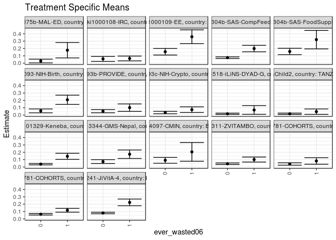

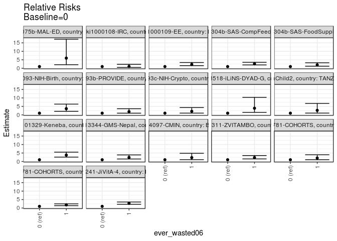

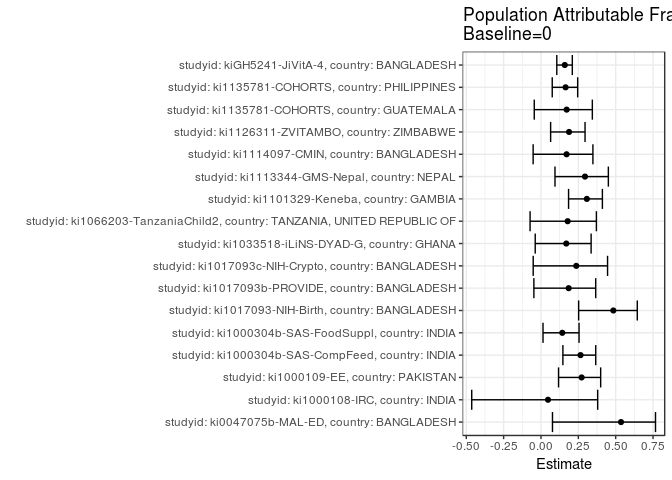

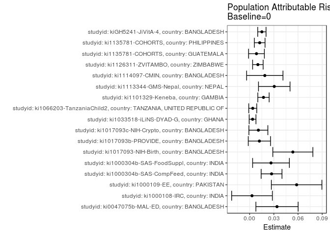

## Results Table

### Parameter: TSM

| studyid | country | intervention_level | baseline_level | estimate | ci_lower | ci_upper |
| --- | --- | --- | --- | --- | --- | --- |
| ki0047075b-MAL-ED | BANGLADESH | 0 | NA | 0.0294118 | 0.0039560 | 0.0548675 |
| ki0047075b-MAL-ED | BANGLADESH | 1 | NA | 0.1764706 | 0.0716073 | 0.2813339 |
| ki1000108-IRC | INDIA | 0 | NA | 0.0588235 | 0.0250579 | 0.0925892 |
| ki1000108-IRC | INDIA | 1 | NA | 0.0642202 | 0.0316381 | 0.0968023 |
| ki1000109-EE | PAKISTAN | 0 | NA | 0.1560000 | 0.1109564 | 0.2010436 |
| ki1000109-EE | PAKISTAN | 1 | NA | 0.3600000 | 0.2657870 | 0.4542130 |
| ki1000304b-SAS-CompFeed | INDIA | 0 | NA | 0.0755873 | 0.0644993 | 0.0866754 |
| ki1000304b-SAS-CompFeed | INDIA | 1 | NA | 0.1992754 | 0.1552777 | 0.2432730 |
| ki1000304b-SAS-FoodSuppl | INDIA | 0 | NA | 0.1592593 | 0.1155450 | 0.2029735 |
| ki1000304b-SAS-FoodSuppl | INDIA | 1 | NA | 0.3207547 | 0.1948960 | 0.4466134 |
| ki1017093-NIH-Birth | BANGLADESH | 0 | NA | 0.0570470 | 0.0306853 | 0.0834086 |
| ki1017093-NIH-Birth | BANGLADESH | 1 | NA | 0.2085890 | 0.1461476 | 0.2710303 |
| ki1017093b-PROVIDE | BANGLADESH | 0 | NA | 0.0531401 | 0.0315131 | 0.0747671 |
| ki1017093b-PROVIDE | BANGLADESH | 1 | NA | 0.1014493 | 0.0510298 | 0.1518687 |
| ki1017093c-NIH-Crypto | BANGLADESH | 0 | NA | 0.0349345 | 0.0181053 | 0.0517637 |
| ki1017093c-NIH-Crypto | BANGLADESH | 1 | NA | 0.0738636 | 0.0351925 | 0.1125348 |
| ki1033518-iLiNS-DYAD-G | GHANA | 0 | NA | 0.0177083 | 0.0093613 | 0.0260554 |
| ki1033518-iLiNS-DYAD-G | GHANA | 1 | NA | 0.0694444 | 0.0106979 | 0.1281910 |
| ki1066203-TanzaniaChild2 | TANZANIA, UNITED REPUBLIC OF | 0 | NA | 0.0176056 | 0.0087704 | 0.0264409 |
| ki1066203-TanzaniaChild2 | TANZANIA, UNITED REPUBLIC OF | 1 | NA | 0.0468750 | 0.0102388 | 0.0835112 |
| ki1101329-Keneba | GAMBIA | 0 | NA | 0.0386965 | 0.0288443 | 0.0485488 |
| ki1101329-Keneba | GAMBIA | 1 | NA | 0.1453901 | 0.1042373 | 0.1865428 |
| ki1113344-GMS-Nepal | NEPAL | 0 | NA | 0.0731070 | 0.0470132 | 0.0992009 |
| ki1113344-GMS-Nepal | NEPAL | 1 | NA | 0.1736527 | 0.1161475 | 0.2311579 |
| ki1114097-CMIN | BANGLADESH | 0 | NA | 0.0909091 | 0.0507817 | 0.1310365 |
| ki1114097-CMIN | BANGLADESH | 1 | NA | 0.2051282 | 0.0781307 | 0.3321257 |
| ki1126311-ZVITAMBO | ZIMBABWE | 0 | NA | 0.0440852 | 0.0331757 | 0.0549948 |
| ki1126311-ZVITAMBO | ZIMBABWE | 1 | NA | 0.1010101 | 0.0667285 | 0.1352917 |
| ki1135781-COHORTS | GUATEMALA | 0 | NA | 0.0407080 | 0.0244021 | 0.0570138 |
| ki1135781-COHORTS | GUATEMALA | 1 | NA | 0.0816327 | 0.0373397 | 0.1259256 |
| ki1135781-COHORTS | PHILIPPINES | 0 | NA | 0.0630865 | 0.0522040 | 0.0739691 |
| ki1135781-COHORTS | PHILIPPINES | 1 | NA | 0.1173380 | 0.0909362 | 0.1437398 |
| kiGH5241-JiVitA-4 | BANGLADESH | 0 | NA | 0.0798787 | 0.0696009 | 0.0901565 |
| kiGH5241-JiVitA-4 | BANGLADESH | 1 | NA | 0.2241379 | 0.1784848 | 0.2697911 |

### Parameter: E(Y)

| studyid | country | intervention_level | baseline_level | estimate | ci_lower | ci_upper |
| --- | --- | --- | --- | --- | --- | --- |
| ki0047075b-MAL-ED | BANGLADESH | NA | NA | 0.0633484 | 0.0311604 | 0.0955364 |
| ki1000108-IRC | INDIA | NA | NA | 0.0617284 | 0.0382610 | 0.0851958 |
| ki1000109-EE | PAKISTAN | NA | NA | 0.2142857 | 0.1712366 | 0.2573348 |
| ki1000304b-SAS-CompFeed | INDIA | NA | NA | 0.1027888 | 0.0905676 | 0.1150101 |
| ki1000304b-SAS-FoodSuppl | INDIA | NA | NA | 0.1857585 | 0.1432798 | 0.2282372 |
| ki1017093-NIH-Birth | BANGLADESH | NA | NA | 0.1106291 | 0.0819645 | 0.1392936 |
| ki1017093b-PROVIDE | BANGLADESH | NA | NA | 0.0652174 | 0.0446012 | 0.0858336 |
| ki1017093c-NIH-Crypto | BANGLADESH | NA | NA | 0.0457413 | 0.0294659 | 0.0620168 |
| ki1033518-iLiNS-DYAD-G | GHANA | NA | NA | 0.0213178 | 0.0125010 | 0.0301346 |
| ki1066203-TanzaniaChild2 | TANZANIA, UNITED REPUBLIC OF | NA | NA | 0.0214286 | 0.0123577 | 0.0304995 |
| ki1101329-Keneba | GAMBIA | NA | NA | 0.0558405 | 0.0450949 | 0.0665861 |
| ki1113344-GMS-Nepal | NEPAL | NA | NA | 0.1036364 | 0.0781411 | 0.1291317 |
| ki1114097-CMIN | BANGLADESH | NA | NA | 0.1097046 | 0.0698323 | 0.1495770 |
| ki1126311-ZVITAMBO | ZIMBABWE | NA | NA | 0.0542823 | 0.0433730 | 0.0651916 |
| ki1135781-COHORTS | GUATEMALA | NA | NA | 0.0491573 | 0.0332659 | 0.0650487 |
| ki1135781-COHORTS | PHILIPPINES | NA | NA | 0.0755323 | 0.0651490 | 0.0859156 |
| kiGH5241-JiVitA-4 | BANGLADESH | NA | NA | 0.0950226 | 0.0844790 | 0.1055662 |

### Parameter: RR

| studyid | country | intervention_level | baseline_level | estimate | ci_lower | ci_upper |
| --- | --- | --- | --- | --- | --- | --- |
| ki0047075b-MAL-ED | BANGLADESH | 0 | 0 | 1.000000 | 1.0000000 | 1.000000 |
| ki0047075b-MAL-ED | BANGLADESH | 1 | 0 | 6.000000 | 2.0999382 | 17.143362 |
| ki1000108-IRC | INDIA | 0 | 0 | 1.000000 | 1.0000000 | 1.000000 |
| ki1000108-IRC | INDIA | 1 | 0 | 1.091743 | 0.5074701 | 2.348716 |
| ki1000109-EE | PAKISTAN | 0 | 0 | 1.000000 | 1.0000000 | 1.000000 |
| ki1000109-EE | PAKISTAN | 1 | 0 | 2.307692 | 1.5629208 | 3.407366 |
| ki1000304b-SAS-CompFeed | INDIA | 0 | 0 | 1.000000 | 1.0000000 | 1.000000 |
| ki1000304b-SAS-CompFeed | INDIA | 1 | 0 | 2.636359 | 1.9699429 | 3.528219 |
| ki1000304b-SAS-FoodSuppl | INDIA | 0 | 0 | 1.000000 | 1.0000000 | 1.000000 |
| ki1000304b-SAS-FoodSuppl | INDIA | 1 | 0 | 2.014041 | 1.2476775 | 3.251130 |
| ki1017093-NIH-Birth | BANGLADESH | 0 | 0 | 1.000000 | 1.0000000 | 1.000000 |
| ki1017093-NIH-Birth | BANGLADESH | 1 | 0 | 3.656442 | 2.1083344 | 6.341293 |
| ki1017093b-PROVIDE | BANGLADESH | 0 | 0 | 1.000000 | 1.0000000 | 1.000000 |
| ki1017093b-PROVIDE | BANGLADESH | 1 | 0 | 1.909091 | 1.0042706 | 3.629130 |
| ki1017093c-NIH-Crypto | BANGLADESH | 0 | 0 | 1.000000 | 1.0000000 | 1.000000 |
| ki1017093c-NIH-Crypto | BANGLADESH | 1 | 0 | 2.114347 | 1.0379918 | 4.306837 |
| ki1033518-iLiNS-DYAD-G | GHANA | 0 | 0 | 1.000000 | 1.0000000 | 1.000000 |
| ki1033518-iLiNS-DYAD-G | GHANA | 1 | 0 | 3.921568 | 1.4889690 | 10.328421 |
| ki1066203-TanzaniaChild2 | TANZANIA, UNITED REPUBLIC OF | 0 | 0 | 1.000000 | 1.0000000 | 1.000000 |
| ki1066203-TanzaniaChild2 | TANZANIA, UNITED REPUBLIC OF | 1 | 0 | 2.662500 | 1.0517430 | 6.740150 |
| ki1101329-Keneba | GAMBIA | 0 | 0 | 1.000000 | 1.0000000 | 1.000000 |
| ki1101329-Keneba | GAMBIA | 1 | 0 | 3.757185 | 2.5675689 | 5.497980 |
| ki1113344-GMS-Nepal | NEPAL | 0 | 0 | 1.000000 | 1.0000000 | 1.000000 |
| ki1113344-GMS-Nepal | NEPAL | 1 | 0 | 2.375321 | 1.4597236 | 3.865217 |
| ki1114097-CMIN | BANGLADESH | 0 | 0 | 1.000000 | 1.0000000 | 1.000000 |
| ki1114097-CMIN | BANGLADESH | 1 | 0 | 2.256410 | 1.0548754 | 4.826529 |
| ki1126311-ZVITAMBO | ZIMBABWE | 0 | 0 | 1.000000 | 1.0000000 | 1.000000 |
| ki1126311-ZVITAMBO | ZIMBABWE | 1 | 0 | 2.291246 | 1.5054152 | 3.487282 |
| ki1135781-COHORTS | GUATEMALA | 0 | 0 | 1.000000 | 1.0000000 | 1.000000 |
| ki1135781-COHORTS | GUATEMALA | 1 | 0 | 2.005324 | 1.0216109 | 3.936258 |
| ki1135781-COHORTS | PHILIPPINES | 0 | 0 | 1.000000 | 1.0000000 | 1.000000 |
| ki1135781-COHORTS | PHILIPPINES | 1 | 0 | 1.859953 | 1.4007800 | 2.469641 |
| kiGH5241-JiVitA-4 | BANGLADESH | 0 | 0 | 1.000000 | 1.0000000 | 1.000000 |
| kiGH5241-JiVitA-4 | BANGLADESH | 1 | 0 | 2.805980 | 2.2119204 | 3.559587 |

### Parameter: PAR

| studyid | country | intervention_level | baseline_level | estimate | ci_lower | ci_upper |
| --- | --- | --- | --- | --- | --- | --- |
| ki0047075b-MAL-ED | BANGLADESH | 0 | NA | 0.0339367 | 0.0077232 | 0.0601501 |
| ki1000108-IRC | INDIA | 0 | NA | 0.0029049 | -0.0223535 | 0.0281632 |
| ki1000109-EE | PAKISTAN | 0 | NA | 0.0582857 | 0.0269219 | 0.0896495 |
| ki1000304b-SAS-CompFeed | INDIA | 0 | NA | 0.0272015 | 0.0142604 | 0.0401426 |
| ki1000304b-SAS-FoodSuppl | INDIA | 0 | NA | 0.0264993 | 0.0036821 | 0.0493164 |
| ki1017093-NIH-Birth | BANGLADESH | 0 | NA | 0.0535821 | 0.0287195 | 0.0784447 |
| ki1017093b-PROVIDE | BANGLADESH | 0 | NA | 0.0120773 | -0.0017490 | 0.0259036 |
| ki1017093c-NIH-Crypto | BANGLADESH | 0 | NA | 0.0108068 | -0.0009794 | 0.0225931 |
| ki1033518-iLiNS-DYAD-G | GHANA | 0 | NA | 0.0036095 | -0.0006077 | 0.0078267 |
| ki1066203-TanzaniaChild2 | TANZANIA, UNITED REPUBLIC OF | 0 | NA | 0.0038229 | -0.0011380 | 0.0087839 |
| ki1101329-Keneba | GAMBIA | 0 | NA | 0.0171439 | 0.0101016 | 0.0241863 |
| ki1113344-GMS-Nepal | NEPAL | 0 | NA | 0.0305293 | 0.0109690 | 0.0500896 |
| ki1114097-CMIN | BANGLADESH | 0 | NA | 0.0187956 | -0.0037774 | 0.0413685 |
| ki1126311-ZVITAMBO | ZIMBABWE | 0 | NA | 0.0101970 | 0.0036675 | 0.0167265 |
| ki1135781-COHORTS | GUATEMALA | 0 | NA | 0.0084493 | -0.0013712 | 0.0182699 |
| ki1135781-COHORTS | PHILIPPINES | 0 | NA | 0.0124458 | 0.0058336 | 0.0190580 |
| kiGH5241-JiVitA-4 | BANGLADESH | 0 | NA | 0.0151440 | 0.0099873 | 0.0203006 |

### Parameter: PAF

| studyid | country | intervention_level | baseline_level | estimate | ci_lower | ci_upper |
| --- | --- | --- | --- | --- | --- | --- |
| ki0047075b-MAL-ED | BANGLADESH | 0 | NA | 0.5357143 | 0.0769639 | 0.7664650 |
| ki1000108-IRC | INDIA | 0 | NA | 0.0470588 | -0.4635004 | 0.3795035 |
| ki1000109-EE | PAKISTAN | 0 | NA | 0.2720000 | 0.1175359 | 0.3994271 |
| ki1000304b-SAS-CompFeed | INDIA | 0 | NA | 0.2646349 | 0.1465921 | 0.3663500 |
| ki1000304b-SAS-FoodSuppl | INDIA | 0 | NA | 0.1426543 | 0.0136593 | 0.2547792 |
| ki1017093-NIH-Birth | BANGLADESH | 0 | NA | 0.4843400 | 0.2520354 | 0.6444950 |
| ki1017093b-PROVIDE | BANGLADESH | 0 | NA | 0.1851852 | -0.0475415 | 0.3662082 |
| ki1017093c-NIH-Crypto | BANGLADESH | 0 | NA | 0.2362596 | -0.0520926 | 0.4455817 |
| ki1033518-iLiNS-DYAD-G | GHANA | 0 | NA | 0.1693182 | -0.0385197 | 0.3355617 |
| ki1066203-TanzaniaChild2 | TANZANIA, UNITED REPUBLIC OF | 0 | NA | 0.1784037 | -0.0729713 | 0.3708868 |
| ki1101329-Keneba | GAMBIA | 0 | NA | 0.3070161 | 0.1846369 | 0.4110271 |
| ki1113344-GMS-Nepal | NEPAL | 0 | NA | 0.2945811 | 0.0937633 | 0.4508986 |
| ki1114097-CMIN | BANGLADESH | 0 | NA | 0.1713287 | -0.0524818 | 0.3475458 |
| ki1126311-ZVITAMBO | ZIMBABWE | 0 | NA | 0.1878521 | 0.0645535 | 0.2948990 |
| ki1135781-COHORTS | GUATEMALA | 0 | NA | 0.1718837 | -0.0449328 | 0.3437122 |
| ki1135781-COHORTS | PHILIPPINES | 0 | NA | 0.1647744 | 0.0753284 | 0.2455680 |
| kiGH5241-JiVitA-4 | BANGLADESH | 0 | NA | 0.1593721 | 0.1058670 | 0.2096756 |